# NANOSED - Adsorption of metallic nanoparticles to estuarine sediments: what implication for denitrification?

Authors: Nanosed Team

Last update 10/03/2020

```r
# Libraries
library("tidyverse")     # data and plots
library("vegan")         # ecological multivariate analyses
library("dabestr")       # test significance no p-value based
library("envalysis")     # environmental analysis
library("scales")        # map data to aesthetics
library("cowplot")       # arranging plots
```

```r
set.seed(57)
```

```r
# Import data
data <- read.csv("Copper_nanoparticle_estuary_microcosms.csv")
```

#### Changes in microcosms due to salinity

```r
# Select data for salinity comparison
data_sal <- data %>%
  select(EXP, Time, Conc, Size, Salinity, O2, pH, OM,
         NO3wat, NO2wat, NH4wat, NO3sed, NO2sed, NH4sed,
         Cuenv, Feenv) %>%
  filter(EXP == "EXP1" | EXP == "EXP2")

# Transform data with z-score
data_zscores<- scale(data_sal[,c(6:16)],center = T, scale = T) %>% as.data.frame()

# Create factors in metadata
Metadata <- data_sal %>%
  select(Time, Conc, Salinity)
Metadata$Time <- factor(Metadata$Time)
Metadata$Conc <- factor(Metadata$Conc)

# Calculate distance - Euclidean
dis.eucli <- vegdist(data_zscores, method="euclidean", na.rm=TRUE)

# PCoA
pcoa.ord <- cmdscale(dis.eucli, eig = T)

# Create a dataframe to plot the PCoA
PCoA.ord <-data.frame(PCoA1 = pcoa.ord$points[,1], PCoA2 = pcoa.ord$points[,2])
PCoA.ord.df<- merge(PCoA.ord , Metadata, by="row.names", sort = F)
PCoA.ord.df <- PCoA.ord.df[,-1]

# How much % of the variance is explained by the axes?
round(pcoa.ord$eig*100/sum(pcoa.ord$eig),1)
```

```
##  [1] 22.5 19.6 13.9 11.4 10.1  5.8  4.5  4.0  3.5  2.8  1.9  0.0  0.0  0.0  0.0
## [16]  0.0  0.0  0.0  0.0  0.0  0.0  0.0  0.0  0.0  0.0  0.0  0.0  0.0  0.0  0.0
## [31]  0.0  0.0  0.0  0.0  0.0  0.0  0.0  0.0  0.0  0.0  0.0  0.0  0.0  0.0  0.0
## [46]  0.0  0.0  0.0
```

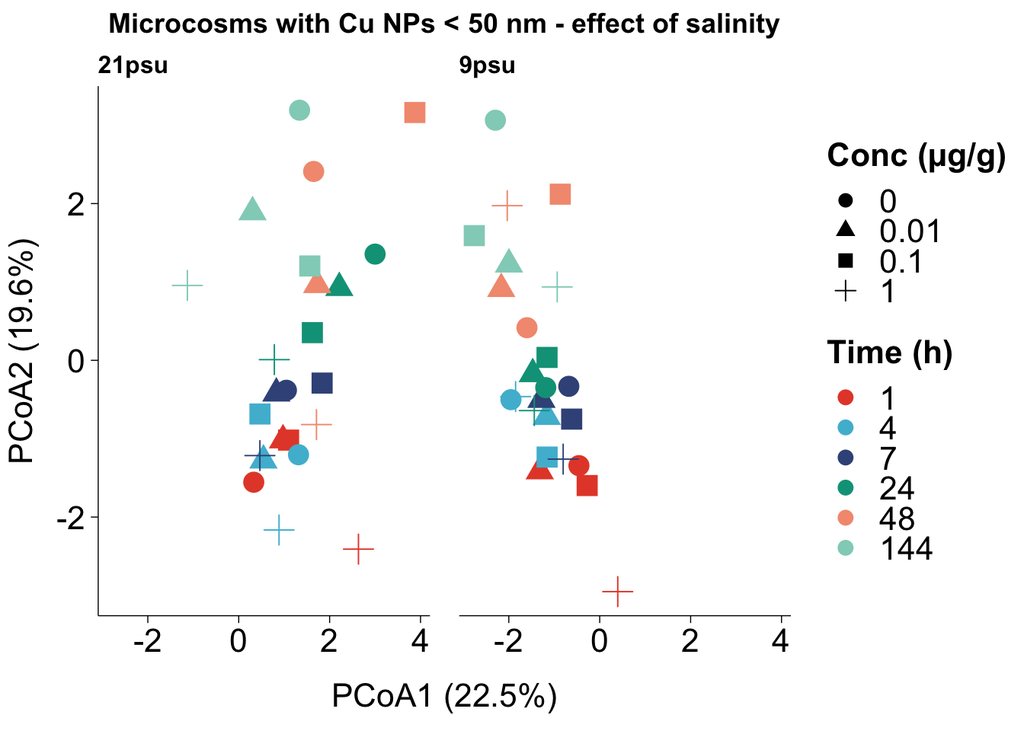

```r
# Plot PCoA
ggplot(data = PCoA.ord.df, aes(PCoA1, PCoA2)) +
  geom_point(aes(color = Time, shape = Conc, size = 1)) +
  labs( y="PCoA2 (19.6%)", x="PCoA1 (22.5%)") +
  facet_wrap(Salinity~.) +
  scale_color_manual(name="Time (h)",
                     labels = c("1","4","7","24","48","144"),
                     values =c ("#E64B35FF","#4DBBD5FF","#3C5488FF","#00A087FF","#F39B7FFF","#91D1C2FF")) +
  scale_shape_manual(name="Conc (µg/g)",
                   labels = c("0","0.01","0.1","1"),
                   values = c(16,17,15,3)) +
  guides(size = F,
         shape = guide_legend(order=1, override.aes = list(size=3)),
         color = guide_legend(order=2, override.aes = list(size=3))) +
  theme_publish() +
  theme(
    axis.title.x = element_text(size=16),
    axis.text.x  = element_text(size=16),
    axis.title.y = element_text(size=16),
    axis.text.y  = element_text(size=16),
    legend.title = element_text(size=16),
    legend.text = element_text(size=16),
    legend.position = "right",
    legend.box = "vertical") +
  ggtitle("Microcosms with Cu NPs < 50 nm - effect of salinity")
```

```r
# Check for differences between Groups - PERMANOVA
adonis2(dis.eucli ~ Salinity*Time, data = Metadata, by ="margin")
```

```
## Permutation test for adonis under reduced model
## Marginal effects of terms
## Permutation: free
## Number of permutations: 999
##
## adonis2(formula = dis.eucli ~ Salinity * Time, data = Metadata, by = "margin")
##               Df SumOfSqs      R2     F Pr(>F)
## Salinity:Time  5    50.73 0.09812 1.571   0.02 *
## Residual      36   232.49 0.44970
## Total         47   517.00 1.00000
## ---
## Signif. codes:  0 '***' 0.001 '**' 0.01 '*' 0.05 '.' 0.1 ' ' 1
```

```r
adonis2(dis.eucli ~ Salinity*Conc, data = Metadata, by ="margin")
```

```
## Permutation test for adonis under reduced model
## Marginal effects of terms
## Permutation: free
## Number of permutations: 999
##
## adonis2(formula = dis.eucli ~ Salinity * Conc, data = Metadata, by = "margin")
##               Df SumOfSqs      R2    F Pr(>F)
## Salinity:Conc  3    12.19 0.02359 0.42  0.997
## Residual      40   387.08 0.74871
## Total         47   517.00 1.00000
```

```r
# Are differences in PERMANOVA due to the dispersion of the results?
beta_dispersion_data <- betadisper(dis.eucli, Metadata$Time)
permutest(beta_dispersion_data)
```

```
##
## Permutation test for homogeneity of multivariate dispersions
## Permutation: free
## Number of permutations: 999
##
## Response: Distances
##           Df Sum Sq Mean Sq      F N.Perm Pr(>F)
## Groups     5 14.428 2.88559 3.2439    999  0.011 *
## Residuals 42 37.361 0.88955
## ---
## Signif. codes:  0 '***' 0.001 '**' 0.01 '*' 0.05 '.' 0.1 ' ' 1
```

```r
# Lm model - linear response

# Create a data frame for each EXP
data_lm_EXP1 <- data_sal %>% filter(EXP == "EXP1")
data_lm_EXP2 <- data_sal %>% filter(EXP == "EXP2")

# EXP1
x1 <- data_lm_EXP1 %>% select(Time)
y1 <- data_lm_EXP1  %>%
  select(O2, pH,  OM, NO3wat, NO2wat, NH4wat, NO3sed, NO2sed, NH4sed, Cuenv, Feenv)

out_lm1 <- data.frame(NULL)
for (i in 1:length(y1)) {
  m1 <- summary(lm(y1[,i] ~ x1[,1]))
  out_lm1[i, 1] <- names(y1)[i]
  out_lm1[i, 2] <- m1$coefficients[1,1]
  out_lm1[i, 3] <- m1$coefficients[2,1]
  out_lm1[i, 4] <- m1$coefficients[2,4]
  }
names(out_lm1) <- c("y.variable", "intercept", "slope", "p.value")
out_lm1
```

```
##    y.variable  intercept         slope      p.value
## 1          O2   4.829433  0.0006508856 6.200573e-01
## 2          pH   7.981335  0.0039560860 1.680825e-04
## 3          OM   1.000466  0.0006785191 1.777686e-01
## 4      NO3wat  20.864963  0.9231588760 9.590297e-07
## 5      NO2wat   1.956647 -0.0033218471 7.121781e-01
## 6      NH4wat  32.589112  0.4761417965 8.987113e-03
## 7      NO3sed   8.497597 -0.0104521241 1.537800e-01
## 8      NO2sed   7.556914  0.0005746438 7.909301e-01
## 9      NH4sed 171.011937  0.4829314822 1.135147e-01
## 10      Cuenv   4.064769 -0.0005311959 9.103007e-01
## 11      Feenv   4.494576  0.0006032761 8.794034e-01
```

```r
# EXP2
x2 <- data_lm_EXP2 %>% select(Time)
y2 <- data_lm_EXP2  %>%
  select(O2, pH, OM, NO3wat, NO2wat, NH4wat, NO3sed, NO2sed, NH4sed, Cuenv, Feenv)

out_lm2 <- data.frame(NULL)
for (i in 1:length(y2)) {
  m2 <- summary(lm(y2[,i] ~ x2[,1]))
  out_lm2[i, 1] <- names(y2)[i]
  out_lm2[i, 2] <- m2$coefficients[1,1]
  out_lm2[i, 3] <- m2$coefficients[2,1]
  out_lm2[i, 4] <- m2$coefficients[2,4]
  }
names(out_lm2) <- c("y.variable", "intercept", "slope", "p.value")
out_lm2
```

```
##    y.variable   intercept         slope      p.value
## 1          O2   5.1067319  0.0011386336 0.1479815501
## 2          pH   8.0398332  0.0043684246 0.0000225226
## 3          OM   1.0552828 -0.0001499867 0.7367672567
## 4      NO3wat  40.0179924  0.6448335331 0.0002990894
## 5      NO2wat   0.8066772  0.0111948995 0.1477848855
## 6      NH4wat  22.6067482  0.5960066254 0.0032151066
## 7      NO3sed   6.9732200 -0.0011702624 0.8830319807
## 8      NO2sed   7.0232170  0.0012859569 0.0937586073
## 9      NH4sed 107.2260020 -0.1654759289 0.1846422055
## 10      Cuenv   6.4984179  0.0064670728 0.0427071903
## 11      Feenv   4.4555527 -0.0052119124 0.1782939829
```

```r
# T-test to compare slopes of two regressions

#####
fit1_ph <- lm(pH~Time, data_lm_EXP1)
s1_ph <- summary(fit1_ph)$coefficients
fit2_ph <- lm(pH~Time, data_lm_EXP2)
s2_ph <- summary(fit2_ph)$coefficients
#
db_ph <- (s2_ph[2,1]-s1_ph[2,1])
sd_ph <- sqrt(s2_ph[2,2]^2+s1_ph[2,2]^2)
df_ph <- (fit1_ph$df.residual+fit2_ph$df.residual)
td_ph <- db_ph/sd_ph
t_test_ph <- 2*pt(-abs(td_ph), df_ph)
#####
fit1_no3 <- lm(NO3wat~Time, data_lm_EXP1)
s1_no3 <- summary(fit1_no3)$coefficients
fit2_no3 <- lm(NO3wat~Time, data_lm_EXP2)
s2_no3 <- summary(fit2_no3)$coefficients
#
db_no3 <- (s2_no3[2,1]-s1_no3[2,1])
sd_no3 <- sqrt(s2_no3[2,2]^2+s1_no3[2,2]^2)
df_no3 <- (fit1_no3$df.residual+fit2_no3$df.residual)
td_no3 <- db_no3/sd_no3
t_test_no3 <- 2*pt(-abs(td_no3), df_no3)

#####
out_fit <- data.frame(NULL)
  out_fit[1, 1] <- t_test_ph
  out_fit[1, 2] <- t_test_no3
names(out_fit) <- c("pH", "NO3 water")
out_fit
```

```
##          pH NO3 water
## 1 0.7319667 0.1790603
```

For both salinities pH and N-NO3 concentration in water increased over time (p < 0.001). A t-test compared the slopes obtained for each salinity and no differences could be found, showing similar increases over time.

#### Changes in microcosms with different NPs sizes

```r
data_np <- data %>%
  select(EXP, Time, Conc, Size, Salinity, O2, pH, OM,
         NO3wat, NO2wat, NH4wat, NO3sed, NO2sed, NH4sed,
         Cuenv, Feenv, Cuexc, Feexc, DAPI) %>%
  filter(EXP == "EXP50" | EXP == "EXP150")

# Normalize data with z-score
data_np_zscores <- scale(data_np[,c(6:18)], center = T, scale = T) %>% as.data.frame()

# Create factors in metadata
Metadata_np <- data_np %>%
  select(Time, Conc, Size)
Metadata_np$Time <- factor(Metadata_np$Time)
Metadata_np$Conc <- factor(Metadata_np$Conc)

# Calculate distances - Euclidean
dis.eucli.np <- vegdist(data_np_zscores, method="euclidean", na.rm=TRUE)

# PCoA
pcoa.ord.np <- cmdscale(dis.eucli.np, eig = T)

# Create a dataframe to plot the PCoA

# Create a dataframe to plot the PCoA
PCoA.ord.np <-data.frame(PCoA1 = pcoa.ord.np$points[,1], PCoA2 = pcoa.ord.np$points[,2])
PCoA.ord.np.df<- merge(PCoA.ord.np, Metadata_np, by="row.names", sort = F)
PCoA.ord.np.df <- PCoA.ord.np.df[,-1]

# How much % of the variance is explained by the axes?
round(pcoa.ord.np$eig*100/sum(pcoa.ord.np$eig),1)
```

```
##  [1] 28.4 16.1 12.6 10.7  8.2  6.3  3.9  3.7  2.7  2.4  2.2  1.7  1.0  0.0  0.0
## [16]  0.0  0.0  0.0  0.0  0.0  0.0  0.0  0.0  0.0  0.0  0.0  0.0  0.0  0.0  0.0
## [31]  0.0  0.0  0.0  0.0  0.0  0.0  0.0  0.0  0.0  0.0  0.0  0.0  0.0  0.0  0.0
## [46]  0.0  0.0  0.0
```

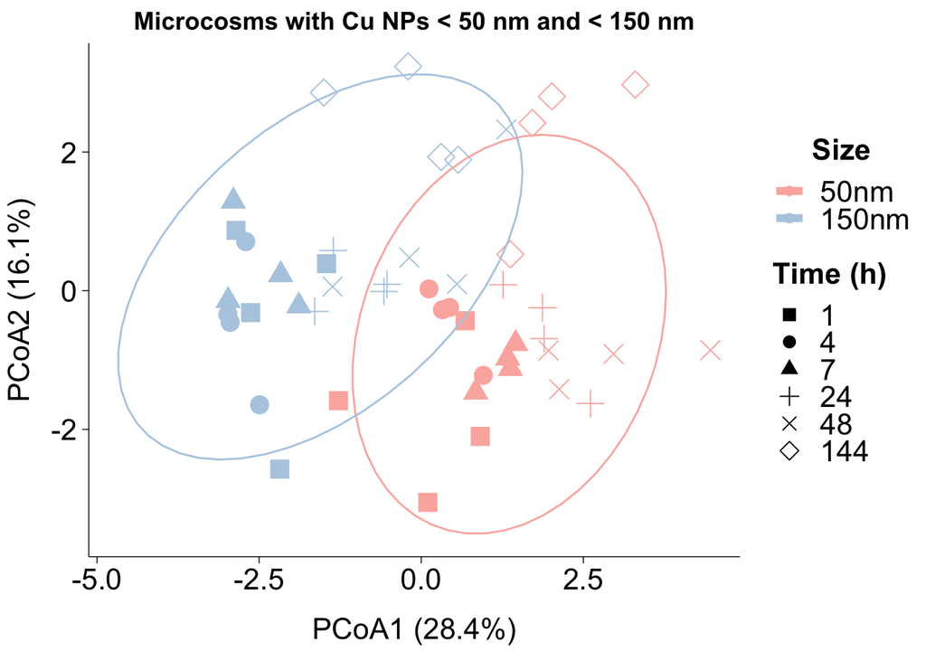

```r
# Order the NPs sizes
PCoA.ord.np.df$Size = factor(PCoA.ord.np.df$Size, levels=c("50nm","150nm"))

# Plot PCoA
ggplot(data = PCoA.ord.np.df, aes(PCoA1, PCoA2)) +
  geom_point(aes(color = Size, shape = Time, size = 1)) +
  stat_ellipse(aes(colour = Size, group = Size)) +
  labs( y="PCoA2 (16.1%)", x="PCoA1 (28.4%)") +
  scale_color_manual(name="Size",
                     labels = c("50nm","150nm"),
                     values = c("#FBB4AE","#B3CDE3")) +
  scale_shape_manual(name="Time (h)",
                     labels = c("1","4","7","24","48","144"),
                     values =c (15,16,17,3,4,5)) +
  guides(size = F,
         shape = guide_legend(order=2, override.aes = list(size=3)),
         color = guide_legend(order=1, override.aes = list(size=2))) +
  theme_publish() +
  theme(
    axis.title.x = element_text(size=16),
    axis.text.x  = element_text(size=16),
    axis.title.y = element_text(size=16),
    axis.text.y  = element_text(size=16),
    legend.title = element_text(size=16),
    legend.text = element_text(size=16),
    legend.position = "right",
    legend.box = "vertical") +
  ggtitle("Microcosms with Cu NPs < 50 nm and < 150 nm")
```

```r
# Check for differences between Groups - PERMANOVA
adonis2(dis.eucli.np ~ Size * Conc, data = Metadata_np)
```

```
## Permutation test for adonis under reduced model
## Terms added sequentially (first to last)
## Permutation: free
## Number of permutations: 999
##
## adonis2(formula = dis.eucli.np ~ Size * Conc, data = Metadata_np)
##           Df SumOfSqs      R2       F Pr(>F)
## Size       1   124.78 0.20422 11.9336  0.001 ***
## Conc       3    34.07 0.05577  1.0863  0.360
## Size:Conc  3    33.90 0.05549  1.0808  0.346
## Residual  40   418.24 0.68452
## Total     47   611.00 1.00000
## ---
## Signif. codes:  0 '***' 0.001 '**' 0.01 '*' 0.05 '.' 0.1 ' ' 1
```

```r
adonis2(dis.eucli.np ~ Size * Time, data = Metadata_np)
```

```
## Permutation test for adonis under reduced model
## Terms added sequentially (first to last)
## Permutation: free
## Number of permutations: 999
##
## adonis2(formula = dis.eucli.np ~ Size * Time, data = Metadata_np)
##           Df SumOfSqs      R2       F Pr(>F)
## Size       1   124.78 0.20422 16.7102  0.001 ***
## Time       5   163.75 0.26801  4.3860  0.001 ***
## Size:Time  5    53.65 0.08780  1.4369  0.050 *
## Residual  36   268.82 0.43997
## Total     47   611.00 1.00000
## ---
## Signif. codes:  0 '***' 0.001 '**' 0.01 '*' 0.05 '.' 0.1 ' ' 1
```

```r
# Are differences in PERMANOVA due to the dispersion of the results?
beta_dispersion_np_size <- betadisper(dis.eucli.np, Metadata_np$Size)
permutest(beta_dispersion_np_size)
```

```
##
## Permutation test for homogeneity of multivariate dispersions
## Permutation: free
## Number of permutations: 999
##
## Response: Distances
##           Df Sum Sq Mean Sq      F N.Perm Pr(>F)
## Groups     1  0.888 0.88765 0.5952    999  0.422
## Residuals 46 68.606 1.49143
```

```r
beta_dispersion_np_time <- betadisper(dis.eucli.np, Metadata_np$Time)
permutest(beta_dispersion_np_time)
```

```
##
## Permutation test for homogeneity of multivariate dispersions
## Permutation: free
## Number of permutations: 999
##
## Response: Distances
##           Df Sum Sq Mean Sq      F N.Perm Pr(>F)
## Groups     5  3.798 0.75959 0.8282    999  0.518
## Residuals 42 38.520 0.91715
```

Principal coordinates analysis shows that for different sizes the microcosms displayed a different behaviour throughout time. PERMANOVA showed size and time as significant. Since the dispersions were not significant the results of the PERMANOVA were interpreted as not reflecting different dispersions.  
To further investigate the effect of time, linear regressions of inorganic N compounds (in water and sediment), metal concentration in sediment (environmentally available and exchangeable), organic matter in sediment (OM), water dissolved O2 and pH were analysed over time.

```r
# Lm model - linear response

# Create a data frame for each EXP
data_lm_EXP50 <- data_np %>% filter(EXP == "EXP50")
data_lm_EXP150 <- data_np %>% filter(EXP == "EXP150")

# EXP50
x1 <- data_lm_EXP50 %>% select(Time)
y1 <- data_lm_EXP50  %>%
  select(O2, pH, OM, NO3wat, NO2wat, NH4wat, NO3sed, NO2sed, NH4sed, Cuenv, Feenv, Cuexc, Feexc, DAPI)

out_lm50 <- data.frame(NULL)
for (i in 1:length(y1)) {
  m1 <- summary(lm(y1[,i] ~ x1[,1]))
  out_lm50[i, 1] <- names(y1)[i]
  out_lm50[i, 2] <- m1$coefficients[1,1]
  out_lm50[i, 3] <- m1$coefficients[2,1]
  out_lm50[i, 4] <- m1$coefficients[2,4]
  }
names(out_lm50) <- c("y.variable", "intercept", "slope", "p.value")
out_lm50
```

```
##    y.variable    intercept         slope      p.value
## 1          O2 4.829433e+00  6.508856e-04 6.200573e-01
## 2          pH 7.981335e+00  3.956086e-03 1.680825e-04
## 3          OM 1.000466e+00  6.785191e-04 1.777686e-01
## 4      NO3wat 2.086496e+01  9.231589e-01 9.590297e-07
## 5      NO2wat 1.956647e+00 -3.321847e-03 7.121781e-01
## 6      NH4wat 3.258911e+01  4.761418e-01 8.987113e-03
## 7      NO3sed 8.497597e+00 -1.045212e-02 1.537800e-01
## 8      NO2sed 7.556914e+00  5.746438e-04 7.909301e-01
## 9      NH4sed 1.710119e+02  4.829315e-01 1.135147e-01
## 10      Cuenv 4.064769e+00 -5.311959e-04 9.103007e-01
## 11      Feenv 4.494576e+00  6.032761e-04 8.794034e-01
## 12      Cuexc 1.489183e-01  2.846584e-05 8.364872e-01
## 13      Feexc 8.434013e-02  1.270142e-04 1.465183e-03
## 14       DAPI 4.493416e+09  4.100166e+06 5.544743e-01
```

```r
# EXP150
x2 <- data_lm_EXP150 %>% select(Time)
y2 <- data_lm_EXP150 %>%
  select(O2, pH, OM, NO3wat, NO2wat, NH4wat, NO3sed, NO2sed, NH4sed, Cuenv, Feenv, Cuexc, Feexc, DAPI)

out_lm150 <- data.frame(NULL)
for (i in 1:length(y2)) {
  m2 <- summary(lm(y2[,i] ~ x2[,1]))
  out_lm150[i, 1] <- names(y2)[i]
  out_lm150[i, 2] <- m2$coefficients[1,1]
  out_lm150[i, 3] <- m2$coefficients[2,1]
  out_lm150[i, 4] <- m2$coefficients[2,4]
  }
names(out_lm150) <- c("y.variable", "intercept", "slope", "p.value")
out_lm150
```

```
##    y.variable    intercept         slope      p.value
## 1          O2 5.226059e+00  1.914369e-04 8.270856e-01
## 2          pH 8.055427e+00  3.442702e-03 1.040778e-03
## 3          OM 1.085170e+00  6.492209e-06 9.860687e-01
## 4      NO3wat 4.756181e+01  2.183405e-01 1.633784e-02
## 5      NO2wat 8.069948e-01  1.668997e-03 8.122793e-01
## 6      NH4wat 2.065949e+01  5.826778e-01 2.280789e-02
## 7      NO3sed 1.095944e+01 -4.410807e-02 1.258039e-03
## 8      NO2sed 6.267966e+00  3.759655e-03 7.726853e-04
## 9      NH4sed 7.479820e+01  1.084685e-01 3.694344e-01
## 10      Cuenv 4.211248e+00  9.199627e-03 8.119996e-03
## 11      Feenv 4.798253e+00 -1.850946e-03 7.306944e-01
## 12      Cuexc 1.010476e-01  5.326941e-06 9.462361e-01
## 13      Feexc 6.182248e-02  1.932681e-04 8.489009e-05
## 14       DAPI 3.552796e+09  1.295537e+06 7.510588e-01
```

```r
# T-test to compare slopes of two regressions

#####
fit1_ph <- lm(pH~Time, data_lm_EXP50)
s1_ph <- summary(fit1_ph)$coefficients
fit2_ph <- lm(pH~Time, data_lm_EXP150)
s2_ph <- summary(fit2_ph)$coefficients
#
db_ph <- (s2_ph[2,1]-s1_ph[2,1])
sd_ph <- sqrt(s2_ph[2,2]^2+s1_ph[2,2]^2)
df_ph <- (fit1_ph$df.residual+fit2_ph$df.residual)
td_ph <- db_ph/sd_ph
t_test_ph <- 2*pt(-abs(td_ph), df_ph)
#####
fit1_no3 <- lm(NO3wat~Time, data_lm_EXP50)
s1_no3 <- summary(fit1_no3)$coefficients
fit2_no3 <- lm(NO3wat~Time, data_lm_EXP150)
s2_no3 <- summary(fit2_no3)$coefficients
#
db_no3 <- (s2_no3[2,1]-s1_no3[2,1])
sd_no3 <- sqrt(s2_no3[2,2]^2+s1_no3[2,2]^2)
df_no3 <- (fit1_no3$df.residual+fit2_no3$df.residual)
td_no3 <- db_no3/sd_no3
t_test_no3 <- 2*pt(-abs(td_no3), df_no3)
#####
fit1_no2 <- lm(NO2sed~Time, data_lm_EXP50)
s1_no2 <- summary(fit1_no2)$coefficients
fit2_no2 <- lm(NO2sed~Time, data_lm_EXP150)
s2_no2 <- summary(fit2_no2)$coefficients
#
db_no2 <- (s2_no2[2,1]-s1_no2[2,1])
sd_no2 <- sqrt(s2_no2[2,2]^2+s1_no2[2,2]^2)
df_no2 <- (fit1_no2$df.residual+fit2_no2$df.residual)
td_no2 <- db_no2/sd_no2
t_test_no2 <- 2*pt(-abs(td_no2), df_no2)
#####
fit1_fe <- lm(Feexc~Time, data_lm_EXP50)
s1_fe <- summary(fit1_fe)$coefficients
fit2_fe <- lm(Feexc~Time, data_lm_EXP150)
s2_fe <- summary(fit2_fe)$coefficients
#
db_fe <- (s2_fe[2,1]-s1_fe[2,1])
sd_fe <- sqrt(s2_fe[2,2]^2+s1_fe[2,2]^2)
df_fe <- (fit1_fe$df.residual+fit2_fe$df.residual)
td_fe <- db_fe/sd_fe
t_test_fe <- 2*pt(-abs(td_fe), df_fe)

#####
out_fit <- data.frame(NULL)
  out_fit[1, 1] <- t_test_ph
  out_fit[1, 2] <- t_test_no3
  out_fit[1, 3] <- t_test_no2
  out_fit[1, 4] <- t_test_fe
  names(out_fit) <- c("pH", "NO3 water", "NO2 sed","Fe exchangeable")
out_fit
```

```
##          pH    NO3 water   NO2 sed Fe exchangeable
## 1 0.6864727 7.404338e-05 0.1819684       0.2203913
```

pH, N-NO3 concentration in water, N-NO2 concentration in sediment and Fe exchangeable fraction in sediment increase over time (p < 0.001) at least for one size of Cu NPs. A t-test compared the slopes of each parameter in microcosms with both Cu NPs sizes and differences could only be found for N-NO3 concentration in water, which increased more on microcosms exposed to Cu NPs < 50 nm.

#### Changes in number of cells

```r
# Create factors in data_np
data_np$Size <- factor(data_np$Size, levels=c("50nm","150nm"))
data_np$Conc <- factor(data_np$Conc)

# Evaluate increases in cell number

# Test for data normality with Anova & Shapiro-Wilk test (if not normal use Kruskal-wallis)
dapi.aov <- aov(DAPI ~ Conc, data = data_np)
dapi.aov_residuals <- residuals(object = dapi.aov)
shapiro.test(x = dapi.aov_residuals)
```

```
##
##  Shapiro-Wilk normality test
##
## data:  dapi.aov_residuals
## W = 0.96433, p-value = 0.1509
```

```r
# Kruskal-wallis
kruskal.test(DAPI ~ Conc, data = data_np)
```

```
##
##  Kruskal-Wallis rank sum test
##
## data:  DAPI by Conc
## Kruskal-Wallis chi-squared = 11.848, df = 3, p-value = 0.007922
```

```r
# If significant compare control without NPs with microcosms with NPs - Wilcoxon signed-rank test
pairwise.wilcox.test(data_np$DAPI, data_np$Conc, p.adjust.method = "BH")
```

```
##
##  Pairwise comparisons using Wilcoxon rank sum test
##
## data:  data_np$DAPI and data_np$Conc
##
##      0     0.01  0.1
## 0.01 0.014 -     -
## 0.1  0.382 0.057 -
## 1    0.057 0.977 0.078
##
## P value adjustment method: BH
```

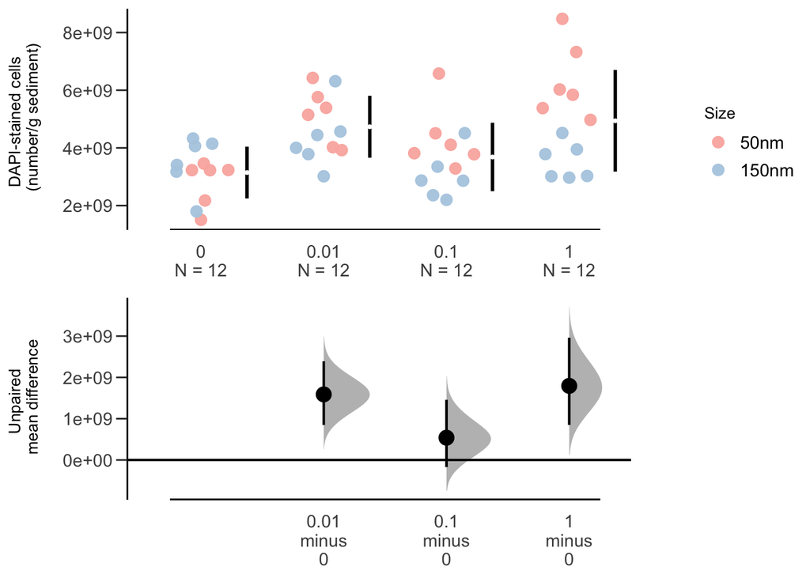

```r
# Estimation plot

DAPI_best <- dabest(data_np, Conc, DAPI,
                             idx = c("0", "0.01", "0.1", "1"),
                             paired = FALSE)

plot(DAPI_best, color.column = Size,
     rawplot.markersize = 3,
     rawplot.ylabel = "DAPI-stained cells \n (number/g sediment)",
     effsize.ylabel = "Unpaired \n mean difference",
     axes.title.fontsize = 10,
     palette = "Pastel1")
```

Kruskal-wallis test shows increases in cell number are significant. An estimation plot shows the mean difference in cell number is higher in microcosms exposed to 0.01 and 1 µg/g Cu NPs < 50 nm.

#### Changes in metal content

```r
# Evaluate increases in metal concentration

# Test for data normality with Anova & Shapiro-Wilk test
cuenv.aov <- aov(Cuenv ~ Conc, data = data_np)
cuenv.aov_residuals <- residuals(object = cuenv.aov)
shapiro.test(x = cuenv.aov_residuals)
```

```
##
##  Shapiro-Wilk normality test
##
## data:  cuenv.aov_residuals
## W = 0.96808, p-value = 0.213
```

```r
# Kruskal-wallis test
kruskal.test(Cuenv ~ Conc, data = data_np)
```

```
##
##  Kruskal-Wallis rank sum test
##
## data:  Cuenv by Conc
## Kruskal-Wallis chi-squared = 1.7012, df = 3, p-value = 0.6367
```

```r
# Test for data normality with Anova & Shapiro-Wilk test
cuexc.aov <- aov(Cuexc ~ Conc, data = data_np)
cuexc.aov_residuals <- residuals(object = cuexc.aov)
shapiro.test(x = cuexc.aov_residuals)
```

```
##
##  Shapiro-Wilk normality test
##
## data:  cuexc.aov_residuals
## W = 0.95231, p-value = 0.04946
```

```r
# Kruskal-wallis test
kruskal.test(Cuexc ~ Conc, data = data_np)
```

```
##
##  Kruskal-Wallis rank sum test
##
## data:  Cuexc by Conc
## Kruskal-Wallis chi-squared = 9.3489, df = 3, p-value = 0.02499
```

```r
pairwise.wilcox.test(data_np$Cuexc, data_np$Conc, p.adjust.method = "BH")
```

```
##
##  Pairwise comparisons using Wilcoxon rank sum test
##
## data:  data_np$Cuexc and data_np$Conc
##
##      0     0.01  0.1
## 0.01 0.907 -     -
## 0.1  0.559 0.559 -
## 1    0.174 0.060 0.021
##
## P value adjustment method: BH
```

```r
# Test for data normality with Anova & Shapiro-Wilk test
feenv.aov <- aov(Feenv ~ Conc, data = data_np)
feenv.aov_residuals <- residuals(object = feenv.aov)
shapiro.test(x = feenv.aov_residuals)
```

```
##
##  Shapiro-Wilk normality test
##
## data:  feenv.aov_residuals
## W = 0.93552, p-value = 0.01096
```

```r
# Kruskal-wallis test (data is not normal)
kruskal.test(Feenv ~ Conc, data = data_np)
```

```
##
##  Kruskal-Wallis rank sum test
##
## data:  Feenv by Conc
## Kruskal-Wallis chi-squared = 1.1539, df = 3, p-value = 0.7641
```

```r
# Test for data normality with Anova & Shapiro-Wilk test
feexc.aov <- aov(Feexc ~ Conc, data = data_np)
feexc.aov_residuals <- residuals(object = feexc.aov)
shapiro.test(x = feexc.aov_residuals)
```

```
##
##  Shapiro-Wilk normality test
##
## data:  feexc.aov_residuals
## W = 0.92739, p-value = 0.005471
```

```r
# Kruskal-wallis test
kruskal.test(Feexc ~ Conc, data = data_np)
```

```
##
##  Kruskal-Wallis rank sum test
##
## data:  Feexc by Conc
## Kruskal-Wallis chi-squared = 0.18445, df = 3, p-value = 0.9801
```

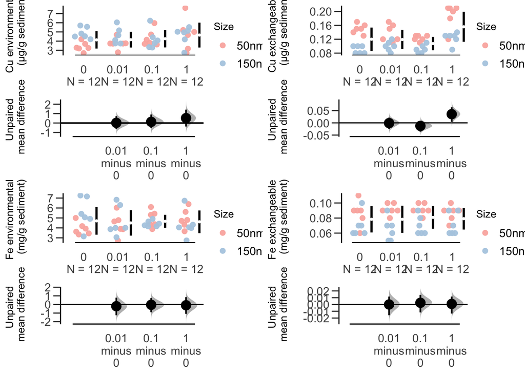

```r
# Estimation plots

Cu_env <- dabest(data_np, Conc, Cuenv,
                             idx = c("0", "0.01", "0.1", "1"),
                             paired = FALSE)
Cu_exc <- dabest(data_np, Conc, Cuexc,
                             idx = c("0", "0.01", "0.1", "1"),
                             paired = FALSE)
Fe_env <- dabest(data_np, Conc, Feenv,
                             idx = c("0", "0.01", "0.1", "1"),
                             paired = FALSE)
Fe_exc <- dabest(data_np, Conc, Feexc,
                             idx = c("0", "0.01", "0.1", "1"),
                             paired = FALSE)

p1<- plot(Cu_env, color.column = Size,
     rawplot.markersize = 2,
     rawplot.ylabel = "Cu environmental \n (µg/g sediment)",
     effsize.ylabel = "Unpaired \n mean difference",
     axes.title.fontsize = 10,
     palette = "Pastel1")
p2<- plot(Cu_exc, color.column = Size,
     rawplot.markersize = 2,
     rawplot.ylabel = "Cu exchangeable \n (µg/g sediment)",
     effsize.ylabel = "Unpaired \n mean difference",
     axes.title.fontsize = 10,
     palette = "Pastel1")
p3<- plot(Fe_env, color.column = Size,
     rawplot.markersize = 2,
     rawplot.ylabel = "Fe environmental \n (mg/g sediment)",
     effsize.ylabel = "Unpaired \n mean difference",
     axes.title.fontsize = 10,
     palette = "Pastel1")
p4<- plot(Fe_exc, color.column = Size,
     rawplot.markersize = 2,
     rawplot.ylabel = "Fe exchangeable \n (mg/g sediment)",
     effsize.ylabel = "Unpaired \n mean difference",
     axes.title.fontsize = 10,
     palette = "Pastel1")

plot_grid1 <- plot_grid(p1, p2, p3, p4,
          ncol=2, nrow=2)
plot_grid1
```

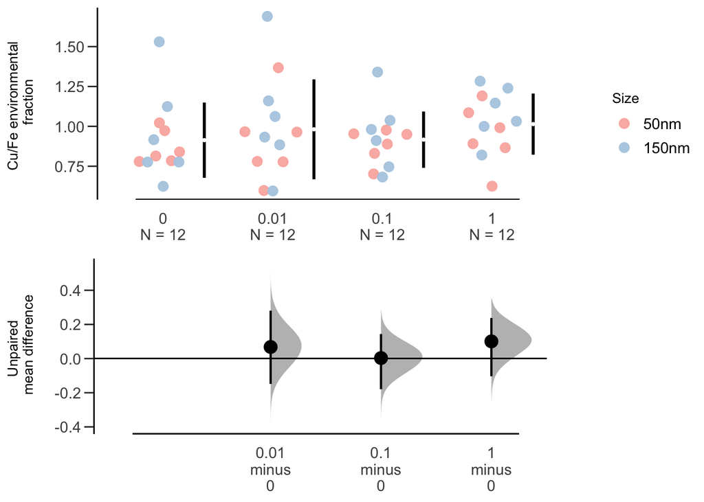

```r
# Normalise Cu concentration

data_np <- transform(data_np, ratiocuenv = Cuenv / Feenv)

ratio_Cu <- dabest(data_np, Conc, ratiocuenv,
                             idx = c("0", "0.01", "0.1", "1"),
                             paired = FALSE)
plot(ratio_Cu , color.column = Size,
     rawplot.markersize = 3,
      rawplot.ylabel = "Cu/Fe environmental \n fraction",
     effsize.ylabel = "Unpaired \n mean difference",
     axes.title.fontsize = 10,
     palette = "Pastel1")
```

Kruskal-wallis test shows increases in Cu exchangeable fraction slightly significant. An estimation plot shows the mean difference in Cu exchangeable concentration is higher in microcosms exposed to 1 µg/g Cu NPs < 50 nm.

#### Can 16S be used as reference gene?

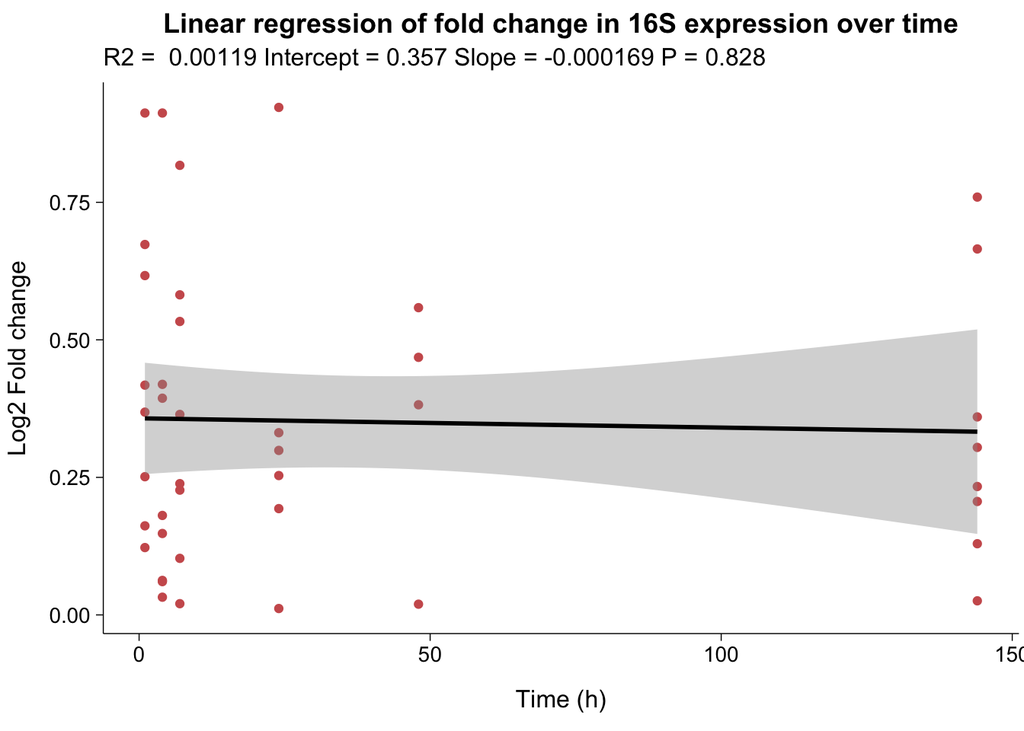

```r
# Import data
data_reference <- data %>%
  select(EXP, Time, Foldch16S)  %>%
  filter(EXP == "EXP50" | EXP == "EXP150")

ggplotRegression <- function (fit) {

    ggplot(fit$model, aes_string(x = names(fit$model)[2], y = names(fit$model)[1])) +
      geom_point(color = "indianred") +
    ggtitle("Linear regression of fold change in 16S expression over time") +
    theme_publish() +
    ylab("Log2 Fold change") +
    xlab("Time (h)") +
      stat_smooth(method = "lm", color = "black") +
      labs(subtitle = paste("R2 = ", signif(summary(fit)$r.squared, 3),
                         "Intercept =", signif(fit$coef[[1]], 3),
                         "Slope =", signif(fit$coef[[2]], 3),
                         "P =", signif(summary(fit)$coef[2,4], 3)))
    }

ggplotRegression(lm(Foldch16S ~ Time, data = data_reference))
```

16S expression did not change over time, therefore, it can be used as a reference gene.

#### Changes gene expression

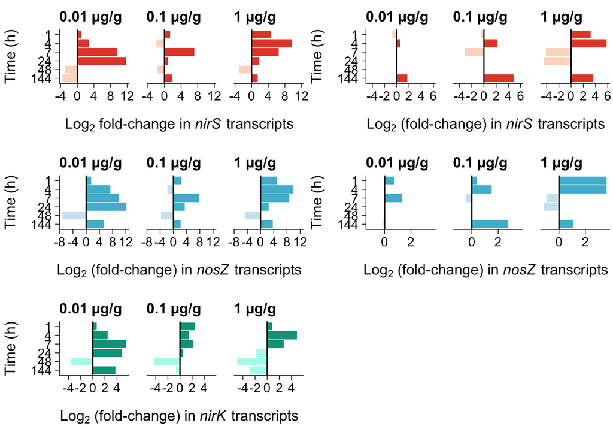

```r
data_gene <- data %>%
  select(EXP, Time, Conc, Size, nosZ, nirS, nirK) %>%
  filter(EXP == "EXP50" | EXP == "EXP150") %>%
  filter(Conc != "0")

data_gene$Conc <- factor(data_gene$Conc)
data_gene$Time <- factor(data_gene$Time, levels = rev(unique(data_gene$Time)))

conc.labs <- c("0 µg/g","0.01 µg/g", "0.1 µg/g", "1 µg/g")
names(conc.labs) <- c("0","0.01", "0.1", "1")

plot_nirS50 <- ggplot(data_gene %>% filter(EXP=="EXP50"), aes(x = Time, y = nirS, fill = nirS>0)) +
  geom_bar(stat = "identity", position = "dodge") +
  facet_grid(~Conc, labeller = labeller(Conc = conc.labs)) +
  scale_fill_manual(values = c("#FDDBC7","#E64B35FF")) +
  ylab(expression(paste("Log"[2], " fold-change in ", italic("nirS"), " transcripts "))) +
  xlab("Time (h)") +
  geom_hline(yintercept = 0) +
  coord_flip() +
  scale_y_continuous(breaks = seq(-8, 14, by = 4)) +
  guides(fill=F) +
  theme_publish()

plot_nirS150 <- ggplot(data_gene %>% filter(EXP=="EXP150"), aes(x = Time, y = nirS, fill = nirS>0)) +
  geom_bar(stat = "identity", position = "dodge") +
  facet_grid(~Conc, labeller = labeller(Conc = conc.labs)) +
  scale_fill_manual(values = c("#FDDBC7","#E64B35FF")) +
  ylab(expression(paste("Log"[2], " (fold-change) in ", italic("nirS"), " transcripts "))) +
  xlab("Time (h)") +
  geom_hline(yintercept = 0) +
  coord_flip() +
  scale_y_continuous(breaks = seq(-6, 6, by = 2)) +
  guides(fill=F) +
  theme_publish()

plot_nosZ50 <- ggplot(data_gene %>% filter(EXP=="EXP50"), aes(x = Time, y = nosZ, fill = nosZ>0)) +
  geom_bar(stat = "identity", position = "dodge") +
  facet_grid(~Conc, labeller = labeller(Conc = conc.labs)) +
  scale_fill_manual(values = c("#D1E5F0","#4DBBD5FF")) +
  ylab(expression(paste("Log"[2], " (fold-change) in ", italic("nosZ"), " transcripts "))) +
  xlab("Time (h)") +
  geom_hline(yintercept = 0) +
  coord_flip() +
  scale_y_continuous(breaks = seq(-8, 14, by = 4)) +
  guides(fill=F) +
  theme_publish()

plot_nosZ150 <- ggplot(data_gene %>% filter(EXP=="EXP150"), aes(x = Time, y = nosZ, fill = nosZ>0)) +
  geom_bar(stat = "identity", position = "dodge") +
  facet_grid(~Conc, labeller = labeller(Conc = conc.labs)) +
  scale_fill_manual(values = c("#D1E5F0","#4DBBD5FF")) +
  ylab(expression(paste("Log"[2], " (fold-change) in ", italic("nosZ"), " transcripts "))) +
  xlab("Time (h)") +
  geom_hline(yintercept = 0) +
  coord_flip() +
  scale_y_continuous(breaks = seq(-6, 6, by = 2)) +
  guides(fill=F) +
  theme_publish()

plot_nirK50 <- ggplot(data_gene %>% filter(EXP=="EXP50"), aes(x = Time, y = nirK, fill = nirK>0)) +
  geom_bar(stat = "identity", position = "dodge") +
  facet_grid(~Conc, labeller = labeller(Conc = conc.labs)) +
  scale_fill_manual(values = c("#AEFCEE","#00A087FF")) +
  ylab(expression(paste("Log"[2], " (fold-change) in ", italic("nirK"), " transcripts "))) +
  xlab("Time (h)") +
  geom_hline(yintercept = 0) +
  coord_flip() +
  scale_y_continuous(breaks = seq(-6, 6, by = 2)) +
  guides(fill=F) +
  theme_publish()

plot_grid2 <- plot_grid(plot_nirS50, plot_nirS150,
                        plot_nosZ50, plot_nosZ150,
                        plot_nirK50,
          ncol=2, nrow=3)
plot_grid2
```

#### Gene copy number

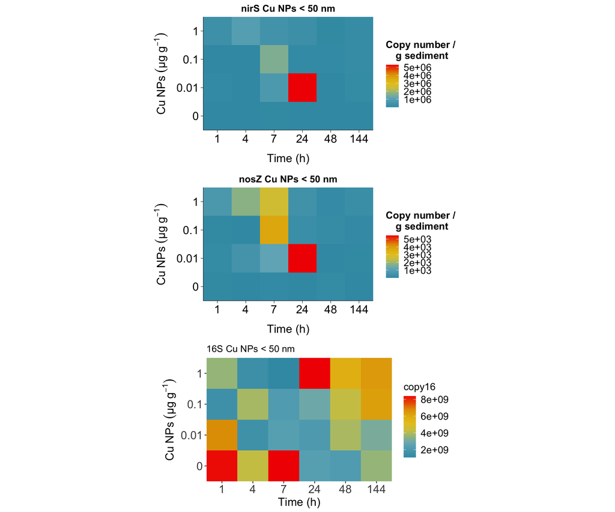

```r
gene_copy <- data %>%
  select(EXP, Time, Conc, copy16, copynos, copynir) %>%
  filter(EXP == "EXP50")

gene_copy$Conc <- factor(gene_copy$Conc)
gene_copy$Time <- factor(gene_copy$Time)

library(wesanderson)
pal <- wes_palette("Zissou1", 10, type = "continuous")

nir50_heatmap <- ggplot(data = gene_copy,
         mapping = aes(x = Time, y = Conc, fill = copynir)) +
  geom_tile() +
  scale_fill_gradientn(colours = pal, name = "Copy number / \ng sediment", label=scientific) +
  scale_x_discrete(expand = c(0, 0)) +
  scale_y_discrete(expand = c(0, 0)) +
  coord_equal() +
  ylab(expression(Cu~NPs~(µg~g^{-1}))) +
  xlab("Time (h)") +
  theme_publish() +
  theme(
    axis.title.x = element_text(size=16),
    axis.text.x  = element_text(size=16),
    axis.title.y = element_text(size=16),
    axis.text.y  = element_text(size=16),
    legend.title = element_text(size=14),
    legend.text = element_text(size=14),
    legend.position = "right") +
  ggtitle("nirS Cu NPs < 50 nm")

nos50_heatmap <- ggplot(data = gene_copy,
         mapping = aes(x = Time, y = Conc, fill = copynos)) +
  geom_tile() +
  scale_fill_gradientn(colours = pal, name = "Copy number / \ng sediment", label=scientific) +
  scale_x_discrete(expand = c(0, 0)) +
  scale_y_discrete(expand = c(0, 0)) +
  coord_equal() +
  ylab(expression(Cu~NPs~(µg~g^{-1}))) +
  xlab("Time (h)") +
  theme_publish() +
  theme(
    axis.title.x = element_text(size=16),
    axis.text.x  = element_text(size=16),
    axis.title.y = element_text(size=16),
    axis.text.y  = element_text(size=16),
    legend.title = element_text(size=14),
    legend.text = element_text(size=14),
    legend.position = "right") +
 ggtitle("nosZ Cu NPs < 50 nm")

ref16S50_heatmap<- ggplot(data = gene_copy,
         mapping = aes(x = Time, y = Conc, fill = copy16)) +
  geom_tile() +
  scale_fill_gradientn(colours = pal) +
  scale_x_discrete(expand = c(0, 0)) +
  scale_y_discrete(expand = c(0, 0)) +
  coord_equal() +
  ylab(expression(Cu~NPs~(µg~g^{-1}))) +
  xlab("Time (h)") +
  theme(
    axis.title.x = element_text(size=16),
    axis.text.x  = element_text(size=16),
    axis.title.y = element_text(size=16),
    axis.text.y  = element_text(size=16),
    legend.title = element_text(size=14),
    legend.text = element_text(size=14),
    legend.position = "right") +
   ggtitle("16S Cu NPs < 50 nm")

plot_grid3 <- plot_grid(nir50_heatmap, nos50_heatmap,ref16S50_heatmap,
                        ncol=1, nrow=3)
plot_grid3
```

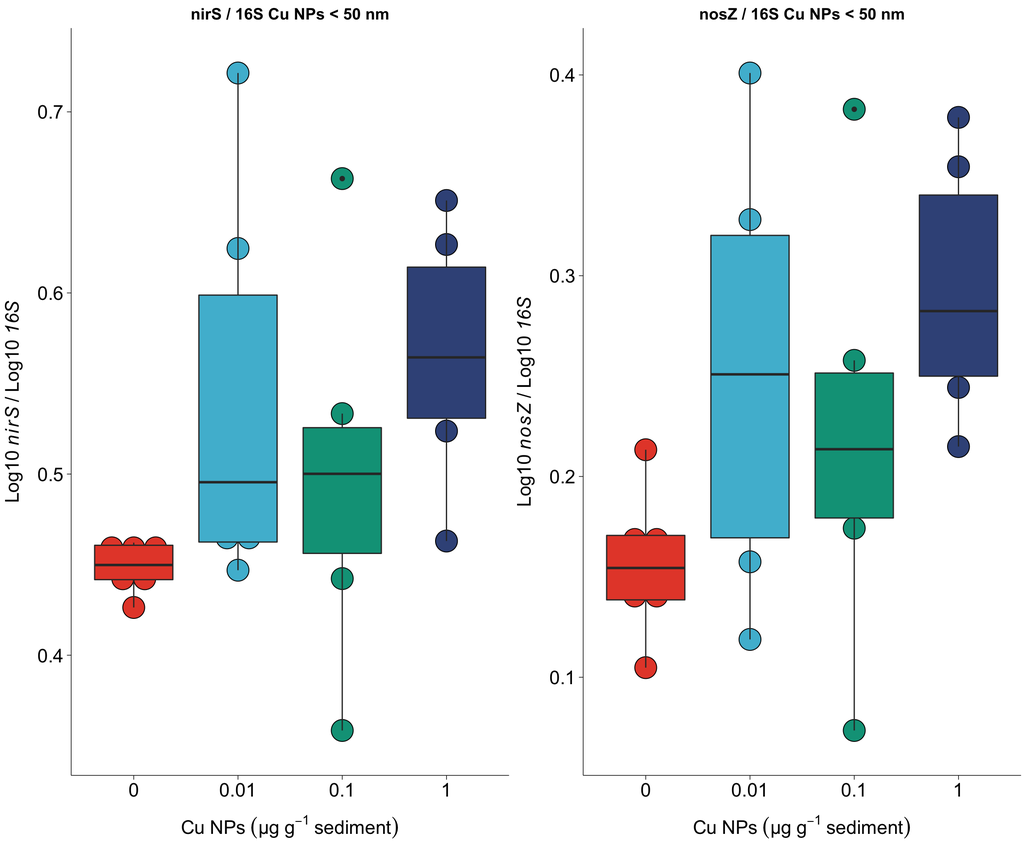

```r
# Create data set for Log copy genes divided by Log 16S

gene_copy_nr<- log10(gene_copy %>% select(copy16, copynos, copynir))
gene_copy_nr<- merge(gene_copy %>% select(Time, Conc), gene_copy_nr, by ="row.names", sort = F)

gene_copy_nr <- transform(gene_copy_nr, lognos = copynos / copy16)
gene_copy_nr <- transform(gene_copy_nr, lognir = copynir / copy16)

plot_gene_nos <-ggplot(gene_copy_nr, aes(x = Conc, y = lognos, fill= Conc)) +
  geom_dotplot(binaxis="y", stackdir="center") +
  geom_boxplot() +
  ylab(expression(Log10~italic(nosZ)~"/"~Log10~italic("16S"))) +
  xlab(expression(Cu~NPs~(µg~g^{-1}~sediment))) +
  scale_fill_manual(values = c("#E64B35FF","#4DBBD5FF","#00A087FF","#3C5488FF")) +
  theme_publish() +
  theme(
    axis.title.x = element_text(size=16),
    axis.text.x  = element_text(size=16),
    axis.title.y = element_text(size=16),
    axis.text.y  = element_text(size=16),
    legend.position ="none") +
  ggtitle("nosZ / 16S Cu NPs < 50 nm")


plot_gene_nir <-ggplot(gene_copy_nr, aes(x = Conc, y = lognir, fill= Conc)) +
  geom_dotplot(binaxis="y", stackdir="center") +
  geom_boxplot() +
  ylab(expression(Log10~italic(nirS)~"/"~Log10~italic("16S"))) +
  xlab(expression(Cu~NPs~(µg~g^{-1}~sediment))) +
  scale_fill_manual(values = c("#E64B35FF","#4DBBD5FF","#00A087FF","#3C5488FF")) +
  theme_publish() +
  theme(
    axis.title.x = element_text(size=16),
    axis.text.x  = element_text(size=16),
    axis.title.y = element_text(size=16),
    axis.text.y  = element_text(size=16),
    legend.position ="none") +
   ggtitle("nirS / 16S Cu NPs < 50 nm")

plot_grid4 <- plot_grid(plot_gene_nir, plot_gene_nos,
                        ncol=2, nrow=1)
plot_grid4
```

```r
# Are these differences significant?

kruskal.test(lognir ~ Conc, data = gene_copy_nr)
```

```
##
##  Kruskal-Wallis rank sum test
##
## data:  lognir by Conc
## Kruskal-Wallis chi-squared = 8.8467, df = 3, p-value = 0.0314
```

```r
pairwise.wilcox.test(gene_copy_nr$lognir, gene_copy_nr$Conc, p.adjust.method = "BH")
```

```
##
##  Pairwise comparisons using Wilcoxon rank sum test
##
## data:  gene_copy_nr$lognir and gene_copy_nr$Conc
##
##      0     0.01  0.1
## 0.01 0.123 -     -
## 0.1  0.360 0.699 -
## 1    0.013 0.473 0.360
##
## P value adjustment method: BH
```

```r
kruskal.test(lognos ~ Conc, data = gene_copy_nr)
```

```
##
##  Kruskal-Wallis rank sum test
##
## data:  lognos by Conc
## Kruskal-Wallis chi-squared = 8.1533, df = 3, p-value = 0.04295
```

```r
pairwise.wilcox.test(gene_copy_nr$lognos, gene_copy_nr$Conc, p.adjust.method = "BH")
```

```
##
##  Pairwise comparisons using Wilcoxon rank sum test
##
## data:  gene_copy_nr$lognos and gene_copy_nr$Conc
##
##      0     0.01  0.1
## 0.01 0.269 -     -
## 0.1  0.269 0.699 -
## 1    0.013 0.582 0.269
##
## P value adjustment method: BH
```

#### Gene copy correl

[figure not shown]

```r
ggplotRegression2 <- function (fit) {

    ggplot(fit$model, aes_string(x = names(fit$model)[2], y = names(fit$model)[1])) +
      geom_point(color = "indianred") +
      stat_smooth(method = "lm", color = "indianred") +
      labs(subtitle = paste("R2 =", signif(summary(fit)$r.squared, 3),
                            "P =", signif(summary(fit)$coef[2,4], 3))) +
      ylab(expression(paste("Log"[10], italic("nirS"), " abundance "))) +
    xlab(expression(paste("Log"[10], italic("nosZ"), " abundance ")))

    }

p10<- ggplotRegression2(lm(copynir ~ copynos, data = gene_copy_nr[gene_copy_nr$Conc=="0",])) +
  ggtitle("0 µg/g") + theme_publish()
p11<- ggplotRegression2(lm(copynir ~ copynos, data = gene_copy_nr[gene_copy_nr$Conc=="0.01",])) +
  ggtitle("0.1 µg/g") + theme_publish()
p12<- ggplotRegression2(lm(copynir ~ copynos, data = gene_copy_nr[gene_copy_nr$Conc=="0.1",])) +
  ggtitle("0.1 µg/g") + theme_publish()
p13<- ggplotRegression2(lm(copynir ~ copynos, data = gene_copy_nr[gene_copy_nr$Conc=="1",])) +
  ggtitle("1 µg/g") + theme_publish()

plot_grid5 <- plot_grid(p10, p11, p12, p13,
                        ncol=2, nrow=2)
plot_grid5
```

#### Denitrification

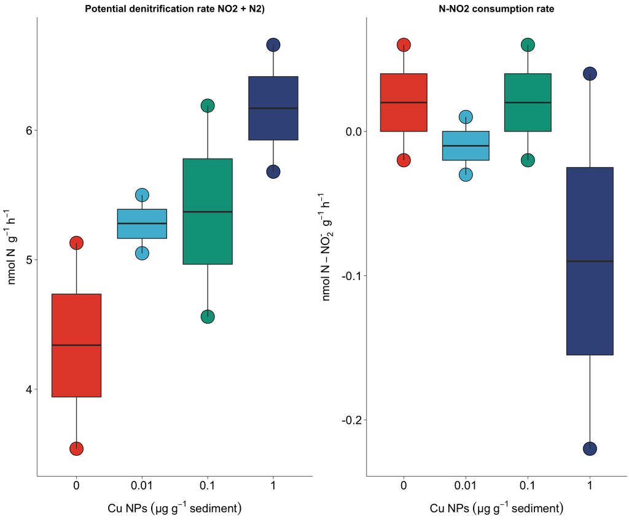

```r
dnf_data <- read.csv("Copper_nanoparticle_estuary_denitrification.csv")

dnf_data$Conc <- factor(dnf_data$Conc)

p14<-ggplot(dnf_data, aes(x=Conc, y=DNF, fill= Conc)) +
  geom_dotplot(binaxis="y", stackdir="center") +
  geom_boxplot() +
  ylab(expression(nmol~N~~g^{-1}~h^{-1})) +
  xlab(expression(Cu~NPs~(µg~g^{-1}~sediment))) +
  scale_fill_manual(values = c("#E64B35FF","#4DBBD5FF","#00A087FF","#3C5488FF")) +
  theme_publish() +
   theme(
    axis.title.x = element_text(size=16),
    axis.text.x  = element_text(size=16),
    axis.title.y = element_text(size=16),
    axis.text.y  = element_text(size=16),
    legend.title = element_text(size=16),
    legend.text = element_text(size=16),
    legend.position ="none") +
   ggtitle("Potential denitrification rate NO2 + N2)")

p15<-ggplot(dnf_data, aes(x=Conc, y=NO2sed, fill= Conc)) +
  geom_dotplot(binaxis="y", stackdir="center") +
  geom_boxplot() +
  ylab(expression(nmol~N-NO[2]^{"-"}~~g^{-1}~h^{-1})) +
  xlab(expression(Cu~NPs~(µg~g^{-1}~sediment))) +
  scale_fill_manual(values = c("#E64B35FF","#4DBBD5FF","#00A087FF","#3C5488FF")) +
  theme_publish() +
   theme(
    axis.title.x = element_text(size=16),
    axis.text.x  = element_text(size=16),
    axis.title.y = element_text(size=16),
    axis.text.y  = element_text(size=16),
    legend.title = element_text(size=16),
    legend.text = element_text(size=16),
    legend.position ="none") +
   ggtitle("N-NO2 consumption rate")

plot_grid6 <- plot_grid(p14,p15,
          ncol=2, nrow=1)
plot_grid6
```

```r
# Are these differences significant?

kruskal.test(DNF ~ Conc, data = dnf_data)
```

```
##
##  Kruskal-Wallis rank sum test
##
## data:  DNF by Conc
## Kruskal-Wallis chi-squared = 6.8974, df = 3, p-value = 0.07524
```

```r
kruskal.test(NO2sed ~ Conc, data = dnf_data)
```

```
##
##  Kruskal-Wallis rank sum test
##
## data:  NO2sed by Conc
## Kruskal-Wallis chi-squared = 2.7079, df = 3, p-value = 0.4389
```